# Two Stage Analysis

Oscar Cabanelas

2023-03-29

```r
library(readxl, knitr)
library(nlme)
library(lme4)
```

```r
library(ggplot2)
trenal <- read_excel("Trenal.XLS") # summary(trenal)
trenal= trenal[,-18] #remove a noninformative column const
# Continuous or discrete variables
trenal$id = as.factor(trenal$id)
trenal$j = as.factor(trenal$j)
#trenal$time = as.factor(trenal$time)
trenal$male = as.factor(trenal$male)
trenal$cardio = as.factor(trenal$cardio)
trenal$reject = as.factor(trenal$reject)
# Change the name of respons
colnames(trenal)[19] <- "Hc"
trenal.long = trenal[,13:20] # long table form

# Remove j
trenal.long = trenal.long[,-6]
trenal.long.unique <- trenal.long[match( unique(trenal.long$id), trenal.long$id),]
trenal.long.noNA <- na.omit(trenal.long)

# Wide table form
trenal.wide = as.data.frame(subset(trenal,trenal$j=="1"))[,1:18] # 1160 x 18
```

### First Step

We need to create a *groupedData* object in order to apply it to the following process.

```r
trenal.long.NA <- na.omit(trenal.long)

trenal_grouped<-groupedData(Hc~time|id,trenal.long.NA, inner = ~ male, labels=list(y="level of Haematocrit"),units=list(y="level of Haematocrit "))
```

A model for each individual estimating the intercept and time was adjusted.

```r
modlist1 <- lmList (Hc ~ time|id, trenal_grouped , na.action = na.pass)
```

Here, he have the model with a beta for each individual.

Then, we can extract all the beta0 and beta1 obtained from the model. This will be used in the following steps and create a data frame in which we store all the betas obtained. This will be useful for trying to split up the analysis by groups.

```r
beta0<- coef(modlist1)[,1]

beta1<- coef(modlist1)[,2]

bbdd<-data.frame(id=as.numeric(attributes(modlist1)$names),
                 beta0=coef(modlist1)[,1],beta1=coef(modlist1)[,2])
bbdd <- merge(trenal.long, bbdd[,c("id","beta0", "beta1")], by.x = "id", all.x = T)

bbdd <- bbdd[order(bbdd[,1]),]
```

#### BETAS ANALYSIS

A descriptive analysis from the beta’s obtaines will be performed in the following section.

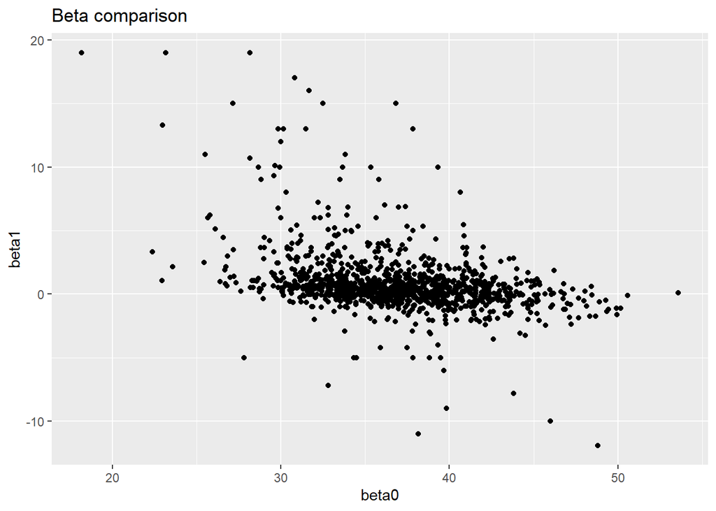

```r
ggplot(bbdd, aes(x=beta0, y=beta1)) + geom_point() + ggtitle("Beta comparison")
```

The betas seem to have a small negative trend between them.

It is interesting to calculate the mean beta by groups, to check if we have significant differences.

```r
(meanbeta0bymale<-tapply(bbdd$beta0,as.factor(bbdd$male),mean,na.rm=T))
```

```
##        0        1
## 35.63671 37.76012
```

```r
(meanbeta1bymale<-tapply(bbdd$beta1,as.factor(bbdd$male),mean,na.rm=T))
```

```
##         0         1
## 0.7635389 0.9452773
```

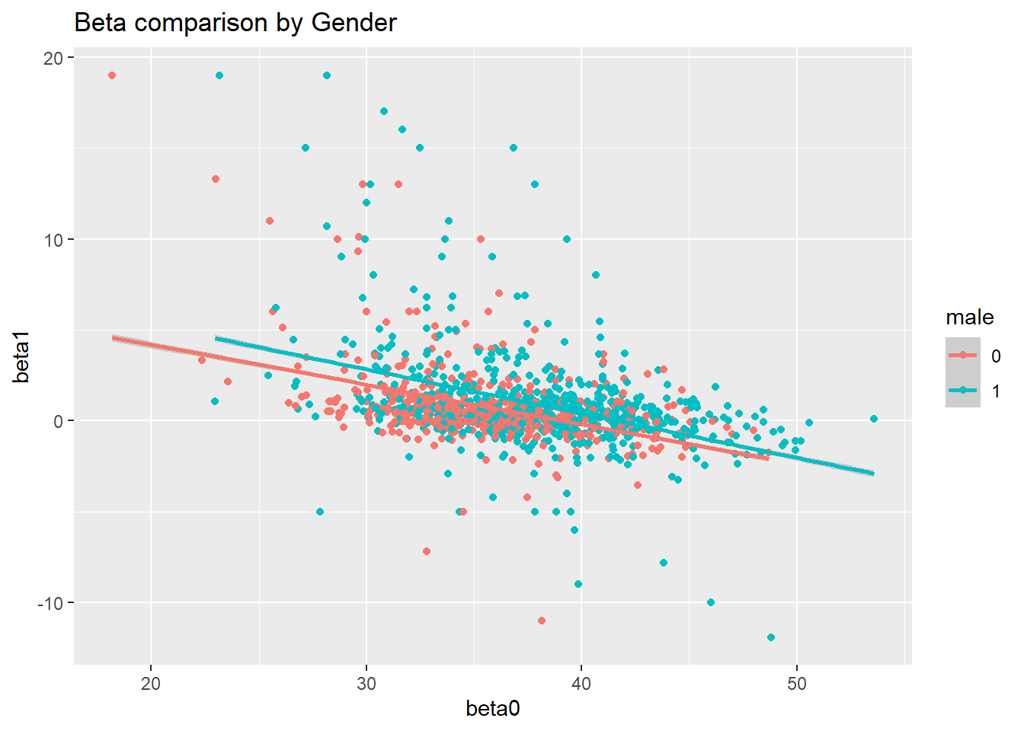

```r
ggplot(bbdd, aes(x=beta0, y=beta1, color=male)) +
geom_point()+
  geom_smooth(method='lm', formula= y~x)+
ggtitle("Beta comparison by Gender")
```

It seems that for gender classification, the intercept is higher for male and also the slope.

```r
(meanbeta0byreject<-tapply(bbdd$beta0,as.factor(bbdd$reject),mean,na.rm=T))
```

```
##        0        1
## 37.03211 36.47146
```

```r
(meanbeta1byreject<-tapply(bbdd$beta1,as.factor(bbdd$reject),mean,na.rm=T))
```

```
##         0         1
## 0.9784599 0.6280845
```

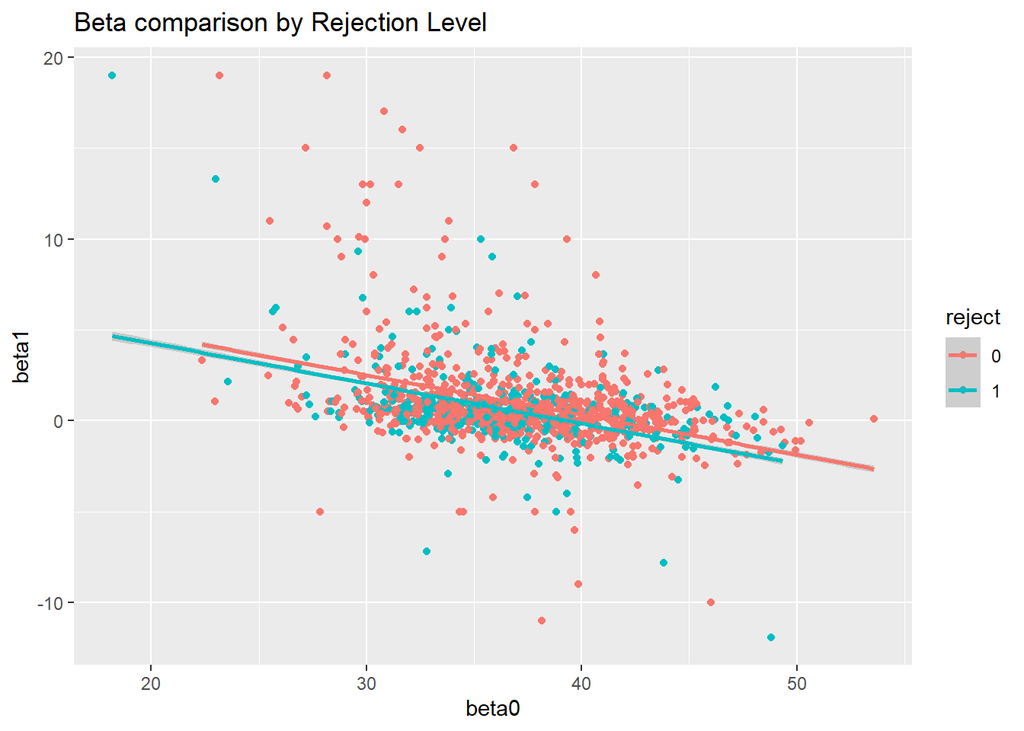

```r
ggplot(bbdd, aes(x=beta0, y=beta1, color=reject)) + geom_point()+
  geom_smooth(method='lm', formula= y~x)+
ggtitle("Beta comparison by Rejection Level")
```

```r
(meanbeta0bycardio<-tapply(bbdd$beta0,as.factor(bbdd$cardio),mean,na.rm=T))
```

```
##        0        1
## 36.79383 37.13667
```

```r
(meanbeta1bycardio<-tapply(bbdd$beta1,as.factor(bbdd$cardio),mean,na.rm=T))
```

```
##         0         1
## 0.7934012 1.2100467
```

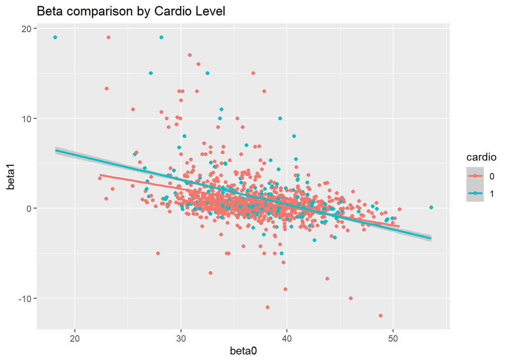

```r
ggplot(bbdd, aes(x=beta0, y=beta1, color=cardio)) + geom_point()+
  geom_smooth(method='lm', formula= y~x)+
ggtitle("Beta comparison by Cardio Level")
```

#### 2nd step

Fit the model and confidence interval. We will use the structure found in the multivariate section.

##### Beta0

```r
modbeta0<-lm(beta0~male + cardio + age,bbdd)
summary(modbeta0)
```

```
##
## Call:
## lm(formula = beta0 ~ male + cardio + age, data = bbdd)
##
## Residuals:
##      Min       1Q   Median       3Q      Max
## -17.3226  -2.9900  -0.0257   2.7011  15.9796
##
## Coefficients:
##              Estimate Std. Error t value Pr(>|t|)
## (Intercept) 33.755491   0.145378 232.191   <2e-16 ***
## male1        2.108912   0.076598  27.532   <2e-16 ***
## cardio1     -0.118084   0.103190  -1.144    0.253
## age          0.041153   0.002971  13.853   <2e-16 ***
## ---
## Signif. codes:  0 '***' 0.001 '**' 0.01 '*' 0.05 '.' 0.1 ' ' 1
##
## Residual standard error: 4.466 on 13904 degrees of freedom
##   (12 observations deleted due to missingness)
## Multiple R-squared:  0.06517,    Adjusted R-squared:  0.06497
## F-statistic: 323.1 on 3 and 13904 DF,  p-value: < 2.2e-16
```

```r
confint(modbeta0)
```

```
##                   2.5 %      97.5 %
## (Intercept) 33.47053026 34.04045245
## male1        1.95877082  2.25905409
## cardio1     -0.32035011  0.08418231
## age          0.03533024  0.04697639
```

From the previous table, we have the following model:

$$\textsf{Respons}_i = 33.75 + 2.1089 *
Male- 0.11 * Cardio + 0.04 * Age + \epsilon_i$$
- The intercept is 33.75. - If a subject is a male, the $\beta_{0}$ increases in 2.11 units. - If a subject experienced a cardio-vascular problem during the years preceding the transplantation. , the $\beta_{0}$ decreases in 0.11 units. - If a subject increases the age, the $\beta_{0}$ increases in 0.04 units.

##### Beta1

```r
### Fit a model for the slope

modbeta1<-lm(beta1~male + cardio + age,bbdd)
summary(modbeta1)
```

```
##
## Call:
## lm(formula = beta1 ~ male + cardio + age, data = bbdd)
##
## Residuals:
##      Min       1Q   Median       3Q      Max
## -12.8417  -1.0587  -0.3697   0.3788  18.0252
##
## Coefficients:
##             Estimate Std. Error t value Pr(>|t|)
## (Intercept) 0.075881   0.083647   0.907    0.364
## male1       0.172159   0.044072   3.906 9.42e-05 ***
## cardio1     0.274666   0.059373   4.626 3.76e-06 ***
## age         0.013873   0.001709   8.116 5.20e-16 ***
## ---
## Signif. codes:  0 '***' 0.001 '**' 0.01 '*' 0.05 '.' 0.1 ' ' 1
##
## Residual standard error: 2.57 on 13904 degrees of freedom
##   (12 observations deleted due to missingness)
## Multiple R-squared:  0.009643,   Adjusted R-squared:  0.00943
## F-statistic: 45.13 on 3 and 13904 DF,  p-value: < 2.2e-16
```

```r
confint(modbeta1)
```

```
##                   2.5 %     97.5 %
## (Intercept) -0.08807846 0.23984145
## male1        0.08577080 0.25854678
## cardio1      0.15828689 0.39104539
## age          0.01052286 0.01722378
```

From the previous table, we have the following model: